# Risk Factor Analysis

## Outcome Variable

**Outcome Variable:** wasted

## Predictor Variables

**Intervention Variable:** exclfeed3

**Adjustment Set:**

- arm
- sex
- W_mage
- meducyrs
- feducyrs
- hhwealth_quart
- hfoodsec
- W_mhtcm
- vagbrth
- W_gagebrth
- W_birthwt
- W_birthlen
- W_nrooms
- W_nchldlt5
- month
- brthmon
- W_parity
- impfloor
- impsan
- safeh20
- delta_W_mage
- delta_meducyrs
- delta_feducyrs
- delta_hhwealth_quart
- delta_hfoodsec
- delta_W_mhtcm
- delta_vagbrth
- delta_W_gagebrth
- delta_W_birthwt
- delta_W_birthlen
- delta_W_nrooms
- delta_W_nchldlt5
- delta_month
- delta_brthmon
- delta_W_parity
- delta_impfloor
- delta_impsan
- delta_safeh20

## Stratifying Variables

The analysis was stratified on these variable(s):

- agecat
- studyid
- country

## Data Summary

| agecat | studyid | country | exclfeed3 | wasted | n_cell | n |
| --- | --- | --- | --- | --- | --- | --- |
| Birth | ki0047075b-MAL-ED | BANGLADESH | 0 | 0 | 54 | 227 |
| Birth | ki0047075b-MAL-ED | BANGLADESH | 0 | 1 | 9 | 227 |
| Birth | ki0047075b-MAL-ED | BANGLADESH | 1 | 0 | 135 | 227 |
| Birth | ki0047075b-MAL-ED | BANGLADESH | 1 | 1 | 29 | 227 |
| Birth | ki0047075b-MAL-ED | BRAZIL | 0 | 0 | 108 | 177 |
| Birth | ki0047075b-MAL-ED | BRAZIL | 0 | 1 | 4 | 177 |
| Birth | ki0047075b-MAL-ED | BRAZIL | 1 | 0 | 63 | 177 |
| Birth | ki0047075b-MAL-ED | BRAZIL | 1 | 1 | 2 | 177 |
| Birth | ki0047075b-MAL-ED | INDIA | 0 | 0 | 57 | 193 |
| Birth | ki0047075b-MAL-ED | INDIA | 0 | 1 | 15 | 193 |
| Birth | ki0047075b-MAL-ED | INDIA | 1 | 0 | 103 | 193 |
| Birth | ki0047075b-MAL-ED | INDIA | 1 | 1 | 18 | 193 |
| Birth | ki0047075b-MAL-ED | NEPAL | 0 | 0 | 91 | 166 |
| Birth | ki0047075b-MAL-ED | NEPAL | 0 | 1 | 15 | 166 |
| Birth | ki0047075b-MAL-ED | NEPAL | 1 | 0 | 55 | 166 |
| Birth | ki0047075b-MAL-ED | NEPAL | 1 | 1 | 5 | 166 |
| Birth | ki0047075b-MAL-ED | PERU | 0 | 0 | 195 | 265 |
| Birth | ki0047075b-MAL-ED | PERU | 0 | 1 | 6 | 265 |
| Birth | ki0047075b-MAL-ED | PERU | 1 | 0 | 64 | 265 |
| Birth | ki0047075b-MAL-ED | PERU | 1 | 1 | 0 | 265 |
| Birth | ki0047075b-MAL-ED | SOUTH AFRICA | 0 | 0 | 185 | 231 |
| Birth | ki0047075b-MAL-ED | SOUTH AFRICA | 0 | 1 | 14 | 231 |
| Birth | ki0047075b-MAL-ED | SOUTH AFRICA | 1 | 0 | 32 | 231 |
| Birth | ki0047075b-MAL-ED | SOUTH AFRICA | 1 | 1 | 0 | 231 |
| Birth | ki0047075b-MAL-ED | TANZANIA, UNITED REPUBLIC OF | 0 | 0 | 74 | 114 |
| Birth | ki0047075b-MAL-ED | TANZANIA, UNITED REPUBLIC OF | 0 | 1 | 2 | 114 |
| Birth | ki0047075b-MAL-ED | TANZANIA, UNITED REPUBLIC OF | 1 | 0 | 38 | 114 |
| Birth | ki0047075b-MAL-ED | TANZANIA, UNITED REPUBLIC OF | 1 | 1 | 0 | 114 |
| Birth | ki1000108-CMC-V-BCS-2002 | INDIA | 0 | 0 | 0 | 4 |
| Birth | ki1000108-CMC-V-BCS-2002 | INDIA | 0 | 1 | 0 | 4 |

[output cut: 146 more lines]

The following strata were considered:

- agecat: 24 months, studyid: ki0047075b-MAL-ED, country: BANGLADESH
- agecat: 24 months, studyid: ki0047075b-MAL-ED, country: BRAZIL
- agecat: 24 months, studyid: ki0047075b-MAL-ED, country: INDIA
- agecat: 24 months, studyid: ki0047075b-MAL-ED, country: NEPAL
- agecat: 24 months, studyid: ki0047075b-MAL-ED, country: PERU
- agecat: 24 months, studyid: ki0047075b-MAL-ED, country: SOUTH AFRICA
- agecat: 24 months, studyid: ki0047075b-MAL-ED, country: TANZANIA, UNITED REPUBLIC OF
- agecat: 24 months, studyid: ki1000108-CMC-V-BCS-2002, country: INDIA
- agecat: 24 months, studyid: ki1000108-IRC, country: INDIA
- agecat: 24 months, studyid: ki1017093b-PROVIDE, country: BANGLADESH
- agecat: 24 months, studyid: ki1101329-Keneba, country: GAMBIA
- agecat: 24 months, studyid: ki1113344-GMS-Nepal, country: NEPAL
- agecat: 24 months, studyid: kiGH5241-JiVitA-3, country: BANGLADESH
- agecat: 24 months, studyid: kiGH5241-JiVitA-4, country: BANGLADESH
- agecat: 6 months, studyid: ki0047075b-MAL-ED, country: BANGLADESH
- agecat: 6 months, studyid: ki0047075b-MAL-ED, country: BRAZIL
- agecat: 6 months, studyid: ki0047075b-MAL-ED, country: INDIA
- agecat: 6 months, studyid: ki0047075b-MAL-ED, country: NEPAL
- agecat: 6 months, studyid: ki0047075b-MAL-ED, country: PERU
- agecat: 6 months, studyid: ki0047075b-MAL-ED, country: SOUTH AFRICA
- agecat: 6 months, studyid: ki0047075b-MAL-ED, country: TANZANIA, UNITED REPUBLIC OF
- agecat: 6 months, studyid: ki1000108-CMC-V-BCS-2002, country: INDIA
- agecat: 6 months, studyid: ki1000108-IRC, country: INDIA
- agecat: 6 months, studyid: ki1000109-EE, country: PAKISTAN
- agecat: 6 months, studyid: ki1000304b-SAS-CompFeed, country: INDIA
- agecat: 6 months, studyid: ki1017093b-PROVIDE, country: BANGLADESH
- agecat: 6 months, studyid: ki1101329-Keneba, country: GAMBIA
- agecat: 6 months, studyid: ki1113344-GMS-Nepal, country: NEPAL
- agecat: 6 months, studyid: kiGH5241-JiVitA-3, country: BANGLADESH
- agecat: 6 months, studyid: kiGH5241-JiVitA-4, country: BANGLADESH
- agecat: Birth, studyid: ki0047075b-MAL-ED, country: BANGLADESH
- agecat: Birth, studyid: ki0047075b-MAL-ED, country: BRAZIL
- agecat: Birth, studyid: ki0047075b-MAL-ED, country: INDIA
- agecat: Birth, studyid: ki0047075b-MAL-ED, country: NEPAL
- agecat: Birth, studyid: ki0047075b-MAL-ED, country: PERU
- agecat: Birth, studyid: ki0047075b-MAL-ED, country: SOUTH AFRICA
- agecat: Birth, studyid: ki0047075b-MAL-ED, country: TANZANIA, UNITED REPUBLIC OF
- agecat: Birth, studyid: ki1000108-CMC-V-BCS-2002, country: INDIA
- agecat: Birth, studyid: ki1000108-IRC, country: INDIA
- agecat: Birth, studyid: ki1000109-EE, country: PAKISTAN
- agecat: Birth, studyid: ki1000304b-SAS-CompFeed, country: INDIA
- agecat: Birth, studyid: ki1101329-Keneba, country: GAMBIA
- agecat: Birth, studyid: kiGH5241-JiVitA-3, country: BANGLADESH
- agecat: Birth, studyid: kiGH5241-JiVitA-4, country: BANGLADESH

### Dropped Strata

Some strata were dropped due to rare outcomes:

- agecat: Birth, studyid: ki0047075b-MAL-ED, country: BRAZIL
- agecat: Birth, studyid: ki0047075b-MAL-ED, country: PERU
- agecat: Birth, studyid: ki0047075b-MAL-ED, country: SOUTH AFRICA
- agecat: Birth, studyid: ki0047075b-MAL-ED, country: TANZANIA, UNITED REPUBLIC OF
- agecat: Birth, studyid: ki1000108-CMC-V-BCS-2002, country: INDIA
- agecat: Birth, studyid: ki1000108-IRC, country: INDIA
- agecat: Birth, studyid: ki1000109-EE, country: PAKISTAN
- agecat: Birth, studyid: ki1000304b-SAS-CompFeed, country: INDIA
- agecat: Birth, studyid: kiGH5241-JiVitA-4, country: BANGLADESH
- agecat: 6 months, studyid: ki0047075b-MAL-ED, country: BANGLADESH
- agecat: 6 months, studyid: ki0047075b-MAL-ED, country: BRAZIL
- agecat: 6 months, studyid: ki0047075b-MAL-ED, country: NEPAL
- agecat: 6 months, studyid: ki0047075b-MAL-ED, country: PERU
- agecat: 6 months, studyid: ki0047075b-MAL-ED, country: SOUTH AFRICA
- agecat: 6 months, studyid: ki0047075b-MAL-ED, country: TANZANIA, UNITED REPUBLIC OF
- agecat: 6 months, studyid: ki1000108-CMC-V-BCS-2002, country: INDIA
- agecat: 6 months, studyid: ki1000108-IRC, country: INDIA
- agecat: 6 months, studyid: ki1000304b-SAS-CompFeed, country: INDIA
- agecat: 6 months, studyid: kiGH5241-JiVitA-4, country: BANGLADESH
- agecat: 24 months, studyid: ki0047075b-MAL-ED, country: BANGLADESH
- agecat: 24 months, studyid: ki0047075b-MAL-ED, country: BRAZIL
- agecat: 24 months, studyid: ki0047075b-MAL-ED, country: NEPAL
- agecat: 24 months, studyid: ki0047075b-MAL-ED, country: PERU
- agecat: 24 months, studyid: ki0047075b-MAL-ED, country: SOUTH AFRICA
- agecat: 24 months, studyid: ki0047075b-MAL-ED, country: TANZANIA, UNITED REPUBLIC OF
- agecat: 24 months, studyid: ki1000108-CMC-V-BCS-2002, country: INDIA
- agecat: 24 months, studyid: ki1000108-IRC, country: INDIA

## Methods Detail

We’re interested in the causal parameters $E[Y_a]$ for all values of $a \in \mathcal{A}$. These parameters represent the mean outcome if, possibly contrary to fact, we intervened to set all units to have $A=a$. Under the randomization and positivity assumptions, these are identified by the statistical parameters $\psi_a=E_W[E_{Y|A,W}(Y|A=a,W)]$. In addition, we’re interested in the mean of $Y$, $E[Y]$ under no intervention (the observed mean). We will estimate these parameters by using SuperLearner to fit the relevant likelihood factors – $E_{Y|A,W}(Y|A=a,W)$ and $p(A=a|W)$, and then updating our likelihood fit using a joint TMLE.

For unadjusted analyses ($W=\{\}$), initial likelihoods were estimated using Lrnr_glm to estimate the simple $E(Y|A)$ and Lrnr_mean to estimate $p(A)$. For adjusted analyses, a small library containing Lrnr_glmnet, Lrnr_xgboost, and Lrnr_mean was used.

Having estimated these parameters, we will then use the delta method to estimate relative risks and attributable risks relative to a prespecified baseline level of $A$.

# Results Detail

## Results Plots

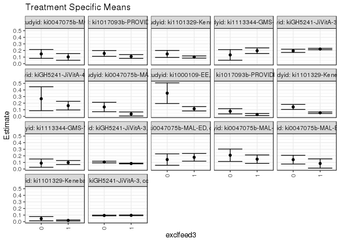

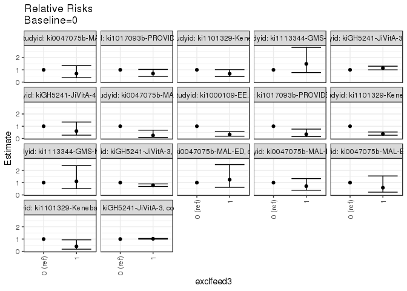

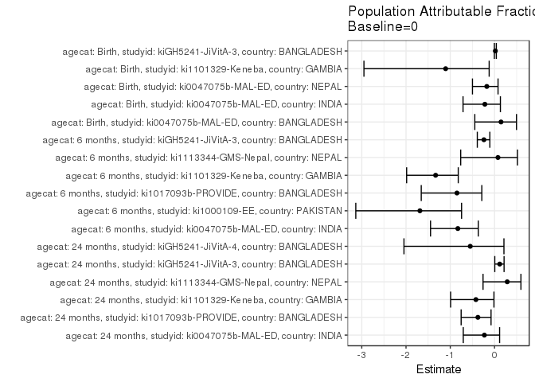

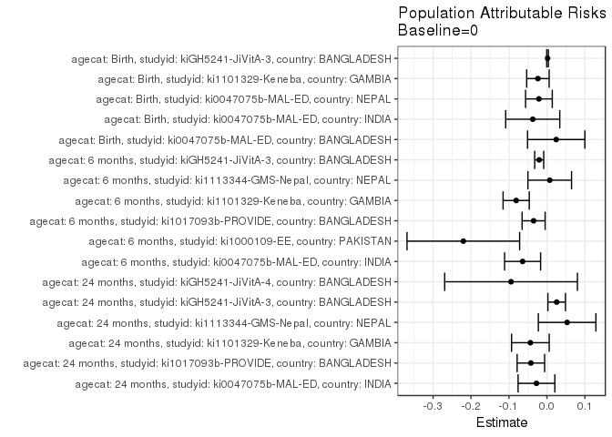

## Results Table

### Parameter: TSM

| agecat | studyid | country | intervention_level | baseline_level | estimate | ci_lower | ci_upper |
| --- | --- | --- | --- | --- | --- | --- | --- |
| Birth | ki0047075b-MAL-ED | BANGLADESH | 0 | NA | 0.1428571 | 0.0562579 | 0.2294564 |
| Birth | ki0047075b-MAL-ED | BANGLADESH | 1 | NA | 0.1768293 | 0.1183089 | 0.2353496 |
| Birth | ki0047075b-MAL-ED | INDIA | 0 | NA | 0.2083333 | 0.1142830 | 0.3023837 |
| Birth | ki0047075b-MAL-ED | INDIA | 1 | NA | 0.1487603 | 0.0851902 | 0.2123304 |
| Birth | ki0047075b-MAL-ED | NEPAL | 0 | NA | 0.1415094 | 0.0749564 | 0.2080624 |
| Birth | ki0047075b-MAL-ED | NEPAL | 1 | NA | 0.0833333 | 0.0131879 | 0.1534788 |
| Birth | ki1101329-Keneba | GAMBIA | 0 | NA | 0.0451613 | 0.0124576 | 0.0778650 |
| Birth | ki1101329-Keneba | GAMBIA | 1 | NA | 0.0182609 | 0.0105194 | 0.0260024 |
| Birth | kiGH5241-JiVitA-3 | BANGLADESH | 0 | NA | 0.0937674 | 0.0881159 | 0.0994190 |
| Birth | kiGH5241-JiVitA-3 | BANGLADESH | 1 | NA | 0.0957592 | 0.0904955 | 0.1010229 |
| 6 months | ki0047075b-MAL-ED | INDIA | 0 | NA | 0.1413043 | 0.0699722 | 0.2126365 |
| 6 months | ki0047075b-MAL-ED | INDIA | 1 | NA | 0.0354610 | 0.0048690 | 0.0660530 |
| 6 months | ki1000109-EE | PAKISTAN | 0 | NA | 0.3509784 | 0.1940216 | 0.5079352 |
| 6 months | ki1000109-EE | PAKISTAN | 1 | NA | 0.1142456 | 0.0809858 | 0.1475054 |
| 6 months | ki1017093b-PROVIDE | BANGLADESH | 0 | NA | 0.0762554 | 0.0363953 | 0.1161156 |
| 6 months | ki1017093b-PROVIDE | BANGLADESH | 1 | NA | 0.0267287 | 0.0111478 | 0.0423095 |
| 6 months | ki1101329-Keneba | GAMBIA | 0 | NA | 0.1418513 | 0.1037714 | 0.1799313 |
| 6 months | ki1101329-Keneba | GAMBIA | 1 | NA | 0.0536743 | 0.0424819 | 0.0648667 |
| 6 months | ki1113344-GMS-Nepal | NEPAL | 0 | NA | 0.0886076 | 0.0258744 | 0.1513408 |
| 6 months | ki1113344-GMS-Nepal | NEPAL | 1 | NA | 0.0976253 | 0.0677111 | 0.1275396 |
| 6 months | kiGH5241-JiVitA-3 | BANGLADESH | 0 | NA | 0.1051660 | 0.0925969 | 0.1177351 |
| 6 months | kiGH5241-JiVitA-3 | BANGLADESH | 1 | NA | 0.0828852 | 0.0778354 | 0.0879350 |
| 24 months | ki0047075b-MAL-ED | INDIA | 0 | NA | 0.1474929 | 0.0798389 | 0.2151469 |
| 24 months | ki0047075b-MAL-ED | INDIA | 1 | NA | 0.1022728 | 0.0512350 | 0.1533106 |
| 24 months | ki1017093b-PROVIDE | BANGLADESH | 0 | NA | 0.1547061 | 0.1105233 | 0.1988889 |
| 24 months | ki1017093b-PROVIDE | BANGLADESH | 1 | NA | 0.1083061 | 0.0792070 | 0.1374051 |
| 24 months | ki1101329-Keneba | GAMBIA | 0 | NA | 0.1469937 | 0.0940460 | 0.1999414 |
| 24 months | ki1101329-Keneba | GAMBIA | 1 | NA | 0.1005337 | 0.0840366 | 0.1170308 |
| 24 months | ki1113344-GMS-Nepal | NEPAL | 0 | NA | 0.1323550 | 0.0517107 | 0.2129994 |
| 24 months | ki1113344-GMS-Nepal | NEPAL | 1 | NA | 0.1964280 | 0.1538945 | 0.2389615 |
| 24 months | kiGH5241-JiVitA-3 | BANGLADESH | 0 | NA | 0.1943922 | 0.1701899 | 0.2185944 |
| 24 months | kiGH5241-JiVitA-3 | BANGLADESH | 1 | NA | 0.2211036 | 0.2104057 | 0.2318015 |
| 24 months | kiGH5241-JiVitA-4 | BANGLADESH | 0 | NA | 0.2666667 | 0.0851884 | 0.4481449 |
| 24 months | kiGH5241-JiVitA-4 | BANGLADESH | 1 | NA | 0.1617647 | 0.0961979 | 0.2273315 |

### Parameter: E(Y)

| agecat | studyid | country | intervention_level | baseline_level | estimate | ci_lower | ci_upper |
| --- | --- | --- | --- | --- | --- | --- | --- |
| Birth | ki0047075b-MAL-ED | BANGLADESH | NA | NA | 0.1674009 | 0.1187276 | 0.2160742 |
| Birth | ki0047075b-MAL-ED | INDIA | NA | NA | 0.1709845 | 0.1177299 | 0.2242391 |
| Birth | ki0047075b-MAL-ED | NEPAL | NA | NA | 0.1204819 | 0.0708125 | 0.1701514 |
| Birth | ki1101329-Keneba | GAMBIA | NA | NA | 0.0214559 | 0.0135914 | 0.0293205 |
| Birth | kiGH5241-JiVitA-3 | BANGLADESH | NA | NA | 0.0955338 | 0.0902714 | 0.1007962 |
| 6 months | ki0047075b-MAL-ED | INDIA | NA | NA | 0.0772532 | 0.0428971 | 0.1116093 |
| 6 months | ki1000109-EE | PAKISTAN | NA | NA | 0.1306667 | 0.0965090 | 0.1648243 |
| 6 months | ki1017093b-PROVIDE | BANGLADESH | NA | NA | 0.0412371 | 0.0250690 | 0.0574052 |
| 6 months | ki1101329-Keneba | GAMBIA | NA | NA | 0.0608496 | 0.0496205 | 0.0720787 |
| 6 months | ki1113344-GMS-Nepal | NEPAL | NA | NA | 0.0960699 | 0.0690520 | 0.1230877 |
| 6 months | kiGH5241-JiVitA-3 | BANGLADESH | NA | NA | 0.0848459 | 0.0799494 | 0.0897424 |
| 24 months | ki0047075b-MAL-ED | INDIA | NA | NA | 0.1200000 | 0.0774445 | 0.1625555 |
| 24 months | ki1017093b-PROVIDE | BANGLADESH | NA | NA | 0.1124567 | 0.0866788 | 0.1382347 |
| 24 months | ki1101329-Keneba | GAMBIA | NA | NA | 0.1034483 | 0.0876083 | 0.1192882 |
| 24 months | ki1113344-GMS-Nepal | NEPAL | NA | NA | 0.1856436 | 0.1476821 | 0.2236050 |
| 24 months | kiGH5241-JiVitA-3 | BANGLADESH | NA | NA | 0.2201371 | 0.2099559 | 0.2303184 |
| 24 months | kiGH5241-JiVitA-4 | BANGLADESH | NA | NA | 0.1721854 | 0.1107033 | 0.2336676 |

### Parameter: RR

| agecat | studyid | country | intervention_level | baseline_level | estimate | ci_lower | ci_upper |
| --- | --- | --- | --- | --- | --- | --- | --- |
| Birth | ki0047075b-MAL-ED | BANGLADESH | 0 | 0 | 1.0000000 | 1.0000000 | 1.0000000 |
| Birth | ki0047075b-MAL-ED | BANGLADESH | 1 | 0 | 1.2378049 | 0.6204509 | 2.4694313 |
| Birth | ki0047075b-MAL-ED | INDIA | 0 | 0 | 1.0000000 | 1.0000000 | 1.0000000 |
| Birth | ki0047075b-MAL-ED | INDIA | 1 | 0 | 0.7140496 | 0.3834969 | 1.3295201 |
| Birth | ki0047075b-MAL-ED | NEPAL | 0 | 0 | 1.0000000 | 1.0000000 | 1.0000000 |
| Birth | ki0047075b-MAL-ED | NEPAL | 1 | 0 | 0.5888889 | 0.2245312 | 1.5445072 |
| Birth | ki1101329-Keneba | GAMBIA | 0 | 0 | 1.0000000 | 1.0000000 | 1.0000000 |
| Birth | ki1101329-Keneba | GAMBIA | 1 | 0 | 0.4043478 | 0.1747149 | 0.9357939 |
| Birth | kiGH5241-JiVitA-3 | BANGLADESH | 0 | 0 | 1.0000000 | 1.0000000 | 1.0000000 |
| Birth | kiGH5241-JiVitA-3 | BANGLADESH | 1 | 0 | 1.0212412 | 0.9956105 | 1.0475317 |
| 6 months | ki0047075b-MAL-ED | INDIA | 0 | 0 | 1.0000000 | 1.0000000 | 1.0000000 |
| 6 months | ki0047075b-MAL-ED | INDIA | 1 | 0 | 0.2509547 | 0.0923637 | 0.6818509 |
| 6 months | ki1000109-EE | PAKISTAN | 0 | 0 | 1.0000000 | 1.0000000 | 1.0000000 |
| 6 months | ki1000109-EE | PAKISTAN | 1 | 0 | 0.3255061 | 0.1909821 | 0.5547860 |
| 6 months | ki1017093b-PROVIDE | BANGLADESH | 0 | 0 | 1.0000000 | 1.0000000 | 1.0000000 |
| 6 months | ki1017093b-PROVIDE | BANGLADESH | 1 | 0 | 0.3505149 | 0.1602610 | 0.7666288 |
| 6 months | ki1101329-Keneba | GAMBIA | 0 | 0 | 1.0000000 | 1.0000000 | 1.0000000 |
| 6 months | ki1101329-Keneba | GAMBIA | 1 | 0 | 0.3783841 | 0.2698079 | 0.5306537 |
| 6 months | ki1113344-GMS-Nepal | NEPAL | 0 | 0 | 1.0000000 | 1.0000000 | 1.0000000 |
| 6 months | ki1113344-GMS-Nepal | NEPAL | 1 | 0 | 1.1017716 | 0.5093937 | 2.3830305 |
| 6 months | kiGH5241-JiVitA-3 | BANGLADESH | 0 | 0 | 1.0000000 | 1.0000000 | 1.0000000 |
| 6 months | kiGH5241-JiVitA-3 | BANGLADESH | 1 | 0 | 0.7881367 | 0.6919619 | 0.8976787 |
| 24 months | ki0047075b-MAL-ED | INDIA | 0 | 0 | 1.0000000 | 1.0000000 | 1.0000000 |
| 24 months | ki0047075b-MAL-ED | INDIA | 1 | 0 | 0.6934083 | 0.3587543 | 1.3402350 |
| 24 months | ki1017093b-PROVIDE | BANGLADESH | 0 | 0 | 1.0000000 | 1.0000000 | 1.0000000 |
| 24 months | ki1017093b-PROVIDE | BANGLADESH | 1 | 0 | 0.7000763 | 0.4731757 | 1.0357819 |
| 24 months | ki1101329-Keneba | GAMBIA | 0 | 0 | 1.0000000 | 1.0000000 | 1.0000000 |
| 24 months | ki1101329-Keneba | GAMBIA | 1 | 0 | 0.6839317 | 0.4605658 | 1.0156260 |
| 24 months | ki1113344-GMS-Nepal | NEPAL | 0 | 0 | 1.0000000 | 1.0000000 | 1.0000000 |
| 24 months | ki1113344-GMS-Nepal | NEPAL | 1 | 0 | 1.4840994 | 0.7773782 | 2.8333069 |
| 24 months | kiGH5241-JiVitA-3 | BANGLADESH | 0 | 0 | 1.0000000 | 1.0000000 | 1.0000000 |
| 24 months | kiGH5241-JiVitA-3 | BANGLADESH | 1 | 0 | 1.1374101 | 0.9962668 | 1.2985496 |
| 24 months | kiGH5241-JiVitA-4 | BANGLADESH | 0 | 0 | 1.0000000 | 1.0000000 | 1.0000000 |
| 24 months | kiGH5241-JiVitA-4 | BANGLADESH | 1 | 0 | 0.6066176 | 0.2741503 | 1.3422748 |

### Parameter: PAR

| agecat | studyid | country | intervention_level | baseline_level | estimate | ci_lower | ci_upper |
| --- | --- | --- | --- | --- | --- | --- | --- |
| Birth | ki0047075b-MAL-ED | BANGLADESH | 0 | NA | 0.0245437 | -0.0509933 | 0.1000807 |
| Birth | ki0047075b-MAL-ED | INDIA | 0 | NA | -0.0373489 | -0.1086356 | 0.0339378 |
| Birth | ki0047075b-MAL-ED | NEPAL | 0 | NA | -0.0210275 | -0.0562363 | 0.0141813 |
| Birth | ki1101329-Keneba | GAMBIA | 0 | NA | -0.0237054 | -0.0533249 | 0.0059142 |
| Birth | kiGH5241-JiVitA-3 | BANGLADESH | 0 | NA | 0.0017664 | -0.0003616 | 0.0038943 |
| 6 months | ki0047075b-MAL-ED | INDIA | 0 | NA | -0.0640511 | -0.1114896 | -0.0166127 |
| 6 months | ki1000109-EE | PAKISTAN | 0 | NA | -0.2203117 | -0.3687445 | -0.0718789 |
| 6 months | ki1017093b-PROVIDE | BANGLADESH | 0 | NA | -0.0350183 | -0.0653482 | -0.0046885 |
| 6 months | ki1101329-Keneba | GAMBIA | 0 | NA | -0.0810017 | -0.1154881 | -0.0465154 |
| 6 months | ki1113344-GMS-Nepal | NEPAL | 0 | NA | 0.0074623 | -0.0500510 | 0.0649755 |
| 6 months | kiGH5241-JiVitA-3 | BANGLADESH | 0 | NA | -0.0203201 | -0.0321876 | -0.0084526 |
| 24 months | ki0047075b-MAL-ED | INDIA | 0 | NA | -0.0274929 | -0.0759113 | 0.0209255 |
| 24 months | ki1017093b-PROVIDE | BANGLADESH | 0 | NA | -0.0422493 | -0.0784807 | -0.0060180 |
| 24 months | ki1101329-Keneba | GAMBIA | 0 | NA | -0.0435455 | -0.0931581 | 0.0060672 |
| 24 months | ki1113344-GMS-Nepal | NEPAL | 0 | NA | 0.0532886 | -0.0225751 | 0.1291522 |
| 24 months | kiGH5241-JiVitA-3 | BANGLADESH | 0 | NA | 0.0257450 | 0.0025942 | 0.0488957 |
| 24 months | kiGH5241-JiVitA-4 | BANGLADESH | 0 | NA | -0.0944812 | -0.2694561 | 0.0804936 |

### Parameter: PAF

| agecat | studyid | country | intervention_level | baseline_level | estimate | ci_lower | ci_upper |
| --- | --- | --- | --- | --- | --- | --- | --- |
| Birth | ki0047075b-MAL-ED | BANGLADESH | 0 | NA | 0.1466165 | -0.4457968 | 0.4962893 |
| Birth | ki0047075b-MAL-ED | INDIA | 0 | NA | -0.2184343 | -0.7116697 | 0.1326701 |
| Birth | ki0047075b-MAL-ED | NEPAL | 0 | NA | -0.1745283 | -0.4985637 | 0.0794407 |
| Birth | ki1101329-Keneba | GAMBIA | 0 | NA | -1.1048387 | -2.9509798 | -0.1213284 |
| Birth | kiGH5241-JiVitA-3 | BANGLADESH | 0 | NA | 0.0184895 | -0.0040502 | 0.0405233 |
| 6 months | ki0047075b-MAL-ED | INDIA | 0 | NA | -0.8291063 | -1.4462197 | -0.3676735 |
| 6 months | ki1000109-EE | PAKISTAN | 0 | NA | -1.6860592 | -3.1350130 | -0.7448347 |
| 6 months | ki1017093b-PROVIDE | BANGLADESH | 0 | NA | -0.8491942 | -1.6560221 | -0.2874588 |
| 6 months | ki1101329-Keneba | GAMBIA | 0 | NA | -1.3311796 | -1.9860822 | -0.8199092 |
| 6 months | ki1113344-GMS-Nepal | NEPAL | 0 | NA | 0.0776755 | -0.7645088 | 0.5178927 |
| 6 months | kiGH5241-JiVitA-3 | BANGLADESH | 0 | NA | -0.2394943 | -0.3892293 | -0.1058981 |
| 24 months | ki0047075b-MAL-ED | INDIA | 0 | NA | -0.2291076 | -0.7065179 | 0.1147438 |
| 24 months | ki1017093b-PROVIDE | BANGLADESH | 0 | NA | -0.3756941 | -0.7545046 | -0.0786717 |
| 24 months | ki1101329-Keneba | GAMBIA | 0 | NA | -0.4209394 | -0.9922232 | -0.0134751 |
| 24 months | ki1113344-GMS-Nepal | NEPAL | 0 | NA | 0.2870477 | -0.2596545 | 0.5964758 |
| 24 months | kiGH5241-JiVitA-3 | BANGLADESH | 0 | NA | 0.1169497 | 0.0058067 | 0.2156678 |
| 24 months | kiGH5241-JiVitA-4 | BANGLADESH | 0 | NA | -0.5487179 | -2.0466898 | 0.2127432 |